# Revisiting the time dependence of SEI growth, take II

## Peter Attia, last updated March 22, 2020

This notebook is used to explore the time dependence of SEI growth. This notebook is identical to "SEI time dependence.ipynb", save for one difference: it uses profile likelihood confidence intervals instead of asympototic approximate CIs. However, because the differences were negligible, I present the standard approach in the paper for simplicity. This notebook can be run to compare the outputs from the two methods.

```python
import glob
import os
from collections import namedtuple
import numpy as np
import matplotlib.pyplot as plt
from matplotlib import rcParams
import matplotlib.cm as cm
from scipy.optimize import curve_fit
from scipy.signal import find_peaks
import scipy.stats
from scipy.stats.distributions import t
from sklearn.metrics import mean_squared_error, r2_score
import inflect
```

Set plotting settings:

```python
fig_width = 3.25 #ECS spec is 3.25" width
fig_height = (3/4)*fig_width # standard ratio
rcParams['lines.markersize'] = 6
rcParams['lines.linewidth'] = 1.0
rcParams['font.size'] = 7
rcParams['legend.fontsize'] = 7
rcParams['legend.frameon'] = False
rcParams['font.sans-serif'] = 'Arial'
rcParams['mathtext.fontset'] = 'custom'
rcParams['mathtext.rm'] = 'Arial'
rcParams['pdf.fonttype'] = 42
rcParams['ps.fonttype'] = 42
```

## Preliminaries

Set $\alpha$ for 95% CI:

```python
alpha = 0.05 # 95% confidence interval = 100*(1-alpha)
```

Create helper functions for the three functional forms under investigation:

- $y = ax^{0.5}+b$; ("t_onehalf" function)
- $y = ax^{b}$; ("power1" function)
- $y = ax^{b}+c$; ("power2" function)

```python
def t_onehalf(x, a, b):
    return a * x**0.5 + b

def power1(x, a, b):
    return a * x**b

def power2(x, a, b, c):
    return a * x**b + c
```

Create tval wrapper:

```python
def tval(alpha, n, p):
    dof = max(0, n - p) # degrees of freedom
    tval = t.ppf(1 - alpha/2, dof)
    return tval
```

Create functions to calculate CIs using the F test. These asymmetric profile confidence intervals are more representative than the asymptotic approximate symmetrical 95% CIs. In practice, however, I found that the two CIs produce very similar results. See these references for the basic procedure:

- Motulsky and Ransnas (justification for F test)
- [Kemmer and Keller](http://doi.org/10.1038/nprot.2009.182): good illustrations of the pitfalls of linearly approximated 95% CIs
- [Wikipedia](https://en.wikipedia.org/wiki/F-test#Regression_problems)
- [GraphPad profile likelihood confidence intervals](https://www.graphpad.com/guides/prism/8/curve-fitting/reg_how_confidence_intervals_are_c.htm)
- [GraphPad F test](https://www.graphpad.com/guides/prism/7/curve-fitting/reg_howtheftestworks.htm)

These results were cross-checked with R's `anova` function.

```python
def calculate_power1_CIs_from_F_test(xdata, ydata, maxfev=500000, plot=False):

    # Get baseline fit
    popt, pcov = curve_fit(power1, xdata, ydata, maxfev=maxfev)

    n = len(xdata)
    p = len(popt)

    # Calculate SSR
    y_pred = power1(xdata, *popt)
    SSR = np.sum((ydata - y_pred) ** 2)

    # Calculate SSR threshold. 95% CI
    SSR_threshold = SSR * (1 + scipy.stats.f.isf(alpha, 1, n - p) / (n - p) )

    # Preinitialize
    window_size = 0.99 # Scan exponents ranging from [1 - window_size, 1 + window_size]
    n_points = 1000
    exponents_left = np.linspace((1 - window_size)*popt[1], popt[1], n_points)
    exponents_right = np.linspace(popt[1], (1 + window_size)*popt[1], n_points)
    SSR_left = np.zeros((n_points, 1))
    SSR_right = np.zeros((n_points, 1))

    f_mod = lambda x, a: power1(x, a, e)

    # Go through left side of exponent
    for k, e in enumerate(exponents_left):

        popt_left, _ = curve_fit(f_mod, xdata, ydata, maxfev=maxfev)
        y_pred = f_mod(xdata, *popt_left)
        SSR_left[k] = np.sum((ydata - y_pred) ** 2)

    # Go through right side of exponent
    for k, e in enumerate(exponents_right):
        popt_right, _ = curve_fit(f_mod, xdata, ydata, maxfev=maxfev)
        y_pred = f_mod(xdata, *popt_right)
        SSR_right[k] = np.sum((ydata - y_pred) ** 2)

    # Find the intersection points
    try:
        exp_lower_CI = exponents_left[ np.where(SSR_left  < SSR_threshold)[0][0]]
        exp_upper_CI = exponents_right[np.where(SSR_right > SSR_threshold)[0][0]]
        exp_CIs = [exp_lower_CI, exp_upper_CI]
    except IndexError: # CIs are very large; set as undefined
        exp_CIs = [np.nan, np.nan]

    # Plot if interested (useful for debugging/understanding)
    if plot:
        plt.plot(exponents_left, SSR_left)
        plt.plot(exponents_right, SSR_right)
        plt.axhline(SSR, color='k')
        plt.axhline(SSR_threshold, color='k')

    return exp_CIs
```

```python
def calculate_power2_CIs_from_F_test(xdata, ydata, maxfev=500000, plot=False):

    # Get baseline fit
    popt, pcov = curve_fit(power2, xdata, ydata, maxfev=maxfev)

    n = len(xdata)
    p = len(popt)

    # Calculate SSR
    y_pred = power2(xdata, *popt)
    SSR = np.sum((ydata - y_pred) ** 2)

    # Calculate SSR threshold. 95% CI
    SSR_threshold = SSR * (1 + scipy.stats.f.isf(alpha, 1, n - p) / (n - p) )

    # Preinitialize
    window_size = 0.99 # Scan exponents ranging from [1 - window_size, 1 + window_size]
    n_points = 1000
    exponents_left = np.linspace((1 - window_size)*popt[1], popt[1], n_points)
    exponents_right = np.linspace(popt[1], (1 + window_size)*popt[1], n_points)
    SSR_left = np.zeros((n_points, 1))
    SSR_right = np.zeros((n_points, 1))

    f_mod = lambda x, a, c: power2(x, a, e, c)

    # Go through left side of exponent
    for k, e in enumerate(exponents_left):

        popt_left, _ = curve_fit(f_mod, xdata, ydata, maxfev=maxfev)
        y_pred = f_mod(xdata, *popt_left)
        SSR_left[k] = np.sum((ydata - y_pred) ** 2)

    # Go through right side of exponent
    for k, e in enumerate(exponents_right):

        popt_right, _ = curve_fit(f_mod, xdata, ydata, maxfev=maxfev)
        y_pred = f_mod(xdata, *popt_right)
        SSR_right[k] = np.sum((ydata - y_pred) ** 2)

    # Find the intersection points
    try:
        exp_lower_CI = exponents_left[ np.where(SSR_left  < SSR_threshold)[0][0]]
        exp_upper_CI = exponents_right[np.where(SSR_right > SSR_threshold)[0][0]]
        exp_CIs = [exp_lower_CI, exp_upper_CI]
    except IndexError: # CIs are very large; set as undefined
        exp_CIs = [np.nan, np.nan]

    # Plot if interested (useful for debugging/understanding)
    if plot:
        plt.plot(exponents_left, SSR_left)
        plt.plot(exponents_right, SSR_right)
        plt.axhline(SSR, color='k')
        plt.axhline(SSR_threshold, color='k')

    return exp_CIs
```

Define wrapper functions for `curve_fit` that returns both the 95% CIs and either $R^2$ or $R^2_{adj}$. See [here](http://kitchingroup.cheme.cmu.edu/blog/2013/02/12/Nonlinear-curve-fitting-with-parameter-confidence-intervals/) for 95% CI reference (also cross-referenced with MATLAB and R's 95% CI calculations) and [here](https://en.wikipedia.org/wiki/Coefficient_of_determination#Adjusted_R2) for $R^2_{adj}$ reference

```python
def adj_r_squared(r_squared, n, p):
    return 1 - (1 - r_squared) * (n - 1) / (n - p - 1)

def curve_fit_with_r_squared(f, xdata, ydata, maxfev=10000):
    popt, pcov = curve_fit(f, xdata, ydata, maxfev=maxfev)

    n = len(xdata)
    p = len(popt)

    if f.__name__ == 'power1':
        exp_CIs = calculate_power1_CIs_from_F_test(xdata, ydata)
    elif f.__name__ == 'power2':
        exp_CIs = calculate_power2_CIs_from_F_test(xdata, ydata)
    else:
        exp_CIs = None

    # Uncomment below line to use asymptotic, approximated CIs (not recommended)
    #CIs = tval(alpha, n, p) * np.diag(pcov)**0.5

    y_pred = f(xdata, *popt)
    r_sq = r2_score(ydata, y_pred)

    return popt, exp_CIs, r_sq

def curve_fit_with_adj_r_squared(f, xdata, ydata, maxfev=10000):
    popt, pcov = curve_fit(f, xdata, ydata, maxfev=maxfev)

    n = len(xdata)
    p = len(popt)

    if f.__name__ == 'power1':
        exp_CIs = calculate_power1_CIs_from_F_test(xdata, ydata)
    elif f.__name__ == 'power2':
        exp_CIs = calculate_power2_CIs_from_F_test(xdata, ydata)
    else:
        exp_CIs = None

    # Uncomment below line to use asymptotic, approximated CIs (not recommended)
    #CIs = tval(alpha, n, p) * np.diag(pcov)**0.5

    y_pred = f(xdata, *popt)
    r_sq = r2_score(ydata, y_pred)
    adj_r_sq = adj_r_squared(r_sq, n, p)

    return popt, exp_CIs, adj_r_sq
```

## Illustration

First, we show how $t^{0.5}$ models can "look good" but still not capture the true functional form.

Here we illustrate $ y=ax^{0.5}+b $ fits to a $ y=ax^b $ function, along with its residual:

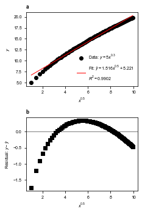

```python
exponent = 0.3

x = np.arange(1, 100) # example data
sqrt_x = np.sqrt(x)
y = 5 * (x**exponent)

popt, CIs, r_squared = curve_fit_with_r_squared(t_onehalf, x, y)

plt.subplots(figsize=(fig_width, fig_height*2), nrows=2)
plt.subplot(211)
plt.title('a', loc='left', weight='bold')

plt.plot(sqrt_x, y, 'ko',
         label='Data: ' + r'$y=5x^{' + str(exponent) + '}$')
plt.plot(sqrt_x, t_onehalf(x, *popt), 'r-',
         label='Fit: ' + r'$\hat{y}=%5.3fx^{0.5} + %5.3f$' % tuple(popt)
         + '\n' + r'$R^2=%3.4f$' %(r_squared))
plt.xlabel(r'$x^{0.5}$')
plt.ylabel(r'$y$')
plt.legend()

plt.subplot(212)
plt.title('b', loc='left', weight='bold')

plt.axhline(0, color='tab:gray')
plt.plot(x**0.5, y-t_onehalf(x, *popt), 'ks')

plt.xlabel(r'$x^{0.5}$')
plt.ylabel(r'Residual: $y-\hat{y}$')

plt.tight_layout()
plt.savefig('figures/example.eps', bbox_inches='tight', format='eps')
```

## WebPlotDigitizer test

The data from the C/10, 30°C series of Figure 7 of [Smith et al.](https://doi.org/10.1149/1.3557892) was extracted with [WebPlotDigitizer](https://automeris.io/WebPlotDigitizer/) using three different extraction techniques from their tool. The figure is reproduced here:

[figure not shown]

```python
csvs = glob.glob('smith/Smith_et_al_2011_Fig7_30degC_Cover10*.{}'.format('csv')) #two-column array, x=t^0.5, y=Qirr
Smith_30C_data = []
data_shape = np.genfromtxt(csvs[0], delimiter=',').shape
x = np.zeros((data_shape[0], 3))
y = np.zeros((data_shape[0], 3))

for k, csv in enumerate(csvs):
    d = np.genfromtxt(csv, delimiter=',')
    Smith_30C_data.append(d)
    x[:,k] = d[:,0]
    y[:,k] = d[:,1]
```

Plot the three extractions together:

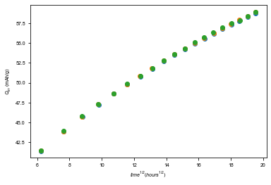

```python
for d in Smith_30C_data:
    plt.plot(d[:,0], d[:,1], 'o')
plt.xlabel(r'$time^{1/2} (hours^{1/2})$')
plt.ylabel(r'$Q_{irr}$ (mAh/g)')
```

Triplicate extractions look very similar. Next. we determine the relative standard error (rse) to quantify the extraction error:

```
Mean relative standard error = 0.095%
Max relative standard error = 0.151%
```

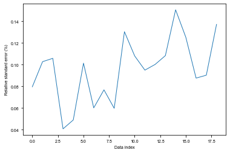

```python
means = np.mean(y, axis=1)
se = 1.96*np.std(y, axis=1)/np.sqrt(3)
rse = se/means*100
plt.plot(rse)
plt.xlabel('Data index')
plt.ylabel('Relative standard error (%)')
print('Mean relative standard error = {:.3f}%'.format(np.mean(rse)))
print('Max relative standard error = {:.3f}%'.format(np.max(rse)))
```

Extraction errors are quite low. For now we'll assume we can accurately extract the data, although of course there could be systematic extraction errors (we don't have the true values for the true quantification).

## Literature data re-analysis

In this section, we systematically reanalyze many purported $ t^{0.5} $ fits from literature.

### Helper functions

We first define a set of helper functions for loading data, plotting, etc:

```python
def sortKeyFunc(s):
    return os.path.basename(s)
```

Create dataset loading function:

```python
def load_dataset(author):
    csvs = glob.glob(author+'/'+author+'_et_al*.{}'.format('csv')) #two-column array
    csvs.sort(key=sortKeyFunc) # glob returns list with arbitrary order

    print(csvs)

    data = []

    for k, csv in enumerate(csvs):
        d = np.genfromtxt(csv,delimiter=',')
        data.append(d)

    return data
```

Create `Labels` `namedtuple` as a container for dataset-specific properties:

```python
Labels = namedtuple('Labels', ['legend_labels', 'x_label', 'y_label', 'dataset_name',
                               'y_symbol', 'y_symbol_pred', 'y_unit', 'switch_xy', 'square_x'])
```

Create helper function for plotting the raw data:

```python
def plot_raw_data_subplot(data, labels, markers):

    x_max = 0

    # account for different types of raw data
    exponent = 1
    if labels.square_x:
        exponent = 2

    # legend tweaking based on number of series
    colon_str = ''
    if len(data) > 1:
        colon_str = ':\n'

    for k, dataset in enumerate(data):

        x = dataset[:,0]**exponent
        y = dataset[:,1]

        if labels.switch_xy:
            x, y = y, x

        x_max = np.max([np.max(x), x_max])

        popt1, CIs1, adj_r2_1 = curve_fit_with_adj_r_squared(t_onehalf, x, y)
        popt2, CIs2, adj_r2_2 = curve_fit_with_adj_r_squared(power1, x, y)
        popt3, CIs3, adj_r2_3 = curve_fit_with_adj_r_squared(power2, x, y)

        # Rounding
        prec2 = -int(np.floor(np.log10(popt2[1] - CIs2[0])))
        try:
            prec3 = -int(np.floor(np.log10(popt3[1] - CIs3[0])))
        except ValueError: # CI = nan
            prec3 = 0

        label = labels.legend_labels[k] + colon_str \
        + r'$' + labels.y_symbol_pred + '=%.3gt^{0.5} %+.3g$' % tuple(popt1) \
        + ', ' + r'$R_{adj}^2=%.4f}$' % adj_r2_1 + '\n' \
        + r'$' + labels.y_symbol_pred + ('=%.3gt^{%.'+str(prec2)+'f }$') % tuple(popt2) \
        + ', ' + r'$R_{adj}^2=%.4f}$' % adj_r2_2 + (', b=[%.'+str(prec2)+'f, %.'+str(prec2)+'f]') % tuple(CIs2) + '\n' \
        + r'$' + labels.y_symbol_pred + ('=%.3gt^{%.'+str(prec3)+'f } %+.3g$') % tuple(popt3) \
        + ', ' + r'$R_{adj}^2=%.4f}$' % adj_r2_3 + (', b=[%.'+str(prec3)+'f, %.'+str(prec3)+'f]') % tuple(CIs3)

        # special case for carbon black data
        if popt3[0] > 1000:
            label = labels.legend_labels[k] + colon_str \
            + r'$' + labels.y_symbol_pred + '=%.3g t^{0.5} %+.3g$' % tuple(popt1) \
            + ', ' + r'$R_{adj}^2=%.4f}$' % adj_r2_1 + '\n' \
            + r'$' + labels.y_symbol_pred + ('=%.3gt^{%.'+str(prec2)+'f}$') % tuple(popt2) \
            + ', ' + r'$R_{adj}^2=%.4f}$' % adj_r2_2 + (', b=[%.'+str(prec2)+'f, %.'+str(prec2)+'f]') % tuple(CIs2) + '\n' \
            + r'$' + labels.y_symbol_pred + ('=%.4g t^{%.'+str(prec3)+'f} %+.4g$') % tuple(popt3) \
            + ', ' + r'$R_{adj}^2=%.4f}$' % adj_r2_3 + (', b=[%.'+str(prec3)+'f, %.'+str(prec3)+'f]') % tuple(CIs3)

        plt.plot(x, y, linestyle='None', marker=markers[k], label=label, color=colors[k])

    plt.xlabel(labels.x_label)
    plt.ylabel('{} {}'.format(labels.y_label, labels.y_unit))

    # Define standard xlim
    print('x_max of dataset = {}'.format(x_max))
    xlim_min = -0.1 * x_max
    xlim_max = 1.15 * x_max
    plt.xlim((xlim_min, xlim_max))

    return (xlim_min, xlim_max)
```

Create helper function for plotting residuals:

```python
def plot_residual_subplot(data, index, labels, xlim, marker):

    colors = cm.viridis(np.linspace(0, 1, 4))
    colors = colors[:,0:3]

    exponent = 1
    if labels.square_x:
        exponent = 2

    x = data[index][:,0]**exponent
    y = data[index][:,1]

    if labels.switch_xy:
        x, y = y, x

    popt1, CIs1, adj_r2_1 = curve_fit_with_adj_r_squared(t_onehalf, x, y)
    popt2, CIs2, adj_r2_2 = curve_fit_with_adj_r_squared(power1, x, y)
    popt3, CIs3, adj_r2_3 = curve_fit_with_adj_r_squared(power2, x, y)

    plt.axhline(0,color='tab:gray')

    plt.plot(x, y - t_onehalf(x, *popt1), marker, color = colors[2, :], label=r'$y=ax^{0.5}+b$')
    plt.plot(x, y - power1(x, *popt2), marker, color = colors[1,:], label=r'$y=ax^{b}$')
    plt.plot(x ,y - power2(x, *popt3), marker, color = colors[0,:], label=r'$y=ax^{b}+c$')

    y_label = 'Residual: '+ r'$' + labels.y_symbol +'-' + labels.y_symbol_pred + '$' + ' ' + labels.y_unit

    plt.xlabel(labels.x_label)
    plt.ylabel(y_label)
    plt.xlim(xlim)

    # annoying hack for Wright dataset
    legend_loc = 'best'
    if labels.dataset_name == 'Wright':
        legend_loc = 'lower right'

    plt.legend(title = labels.legend_labels[index], loc=legend_loc)
```

Helper function for plotting raw data in subplot (a), plotting the residuals of the first and last series in subplots (b) and (c), respectively, and plotting a large legend in the top right quadrant.

```python
def plot_dataset(data, labels):

    # Find number of datasets
    n_datasets = len(data)

    # Initialize figure
    plt.figure(figsize=(fig_width*2, fig_height*2.5))

    # (a): Plot raw data
    ax = plt.subplot(221)
    plt.title('a', loc='left', weight='bold')
    xlim = plot_raw_data_subplot(data, labels, markers)

    # (b): Plot first series
    plt.subplot(223)
    plt.title('b', loc='left', weight='bold')
    plot_residual_subplot(data, 0, labels, xlim, markers[0])

    # (c): Plot last series
    plt.subplot(224)
    plt.title('c', loc='left', weight='bold')
    plot_residual_subplot(data, n_datasets-1, labels, xlim, markers[-1])

    plt.tight_layout()

    ax.legend(bbox_to_anchor=(0.55, 0.75), loc='center left', labelspacing=1.5,
              bbox_transform=plt.gcf().transFigure)

    # Save
    figure_filename = 'figures/{}.eps'.format(labels.dataset_name)
    plt.savefig(figure_filename, bbox_inches='tight', format='eps')
```

### Broussely et al

We use the "proto" datasets here since they are the easiest to extract

[figure not shown]

```python
Broussely_data = load_dataset('Broussely')
```

```
['Broussely/Broussely_et_al_2001_Fig6_30C.csv', 'Broussely/Broussely_et_al_2001_Fig6_60C.csv']
```

```
x_max of dataset = 450.6313751047589
```

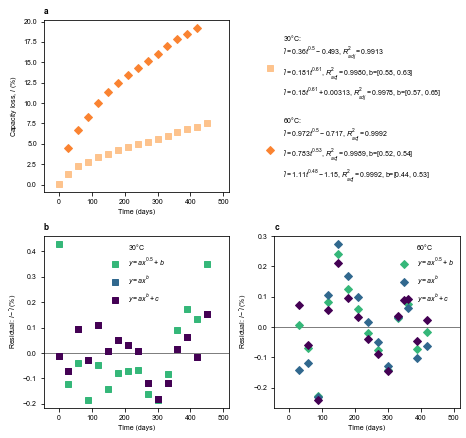

```python
colors = cm.Oranges(np.linspace(0.3, 1, 4))
colors = colors[:,0:3]
markers = ['s','D']

Broussely_labels = Labels(legend_labels = [r'$30\degree$'+'C',r'$60\degree$'+'C'],
                          x_label = 'Time (days)',
                          y_label = 'Capacity loss, ' + r'$l$',
                          dataset_name = 'Broussely',
                          y_symbol = 'l',
                          y_symbol_pred = r'\hat{l}',
                          y_unit = '(%)',
                          switch_xy = True,
                          square_x = False)

plot_dataset(Broussely_data, Broussely_labels)
```

### Wright et al

The 60°C data was hard to extract, so we extract all but that one.

[figure not shown]

```python
Wright_data = load_dataset('Wright')
```

```
['Wright/Wright_et_al_2002_Fig1_40C.csv', 'Wright/Wright_et_al_2002_Fig1_50C.csv', 'Wright/Wright_et_al_2002_Fig1_70C.csv']
```

Convert ohms to milliohms to improve figure readability:

```python
for k in range(len(Wright_data)):
    Wright_data[k][:,1] *= 1000
```

```
x_max of dataset = 27.016774772196914
```

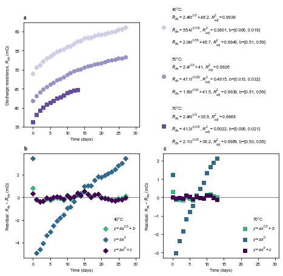

```python
colors = cm.Purples(np.linspace(0.3, 1, 4))
colors = colors[:,0:3]
markers = ['D','o','s']

Wright_labels = Labels(legend_labels = [r'$40\degree$'+'C',r'$50\degree$'+'C',r'$70\degree$'+'C'],
                       x_label = 'Time (days)',
                       y_label = r'Discharge resistance, $R_{dis}$',
                       dataset_name = 'Wright',
                       y_symbol = 'R_{dis}',
                       y_symbol_pred = r'\hat{R}_{dis}',
                       y_unit = r'(m$\Omega$)',
                       switch_xy = False,
                       square_x = True)

plot_dataset(Wright_data, Wright_labels)
```

### Smith et al.

We now look at the rest of the C/10 data in Figure 7 of Smith et al.

We don't use the dataset loading helper function since we just want to load the new Smith et al csvs

```python
# Load other Smith et al csvs
csvs = glob.glob('smith/Smith_et_al_2011_Fig7_[!30]*.{}'.format('csv')) #two-column array, x=t^0.5, y=Qirr
csvs.sort(key=sortKeyFunc) # glob returns list with arbitrary order

print(csvs)

Smith_data = []
Smith_data.append(Smith_30C_data[0]) # 30 deg C

for k, csv in enumerate(csvs):
    d = np.genfromtxt(csv,delimiter=',')
    Smith_data.append(d)
```

```
['smith/Smith_et_al_2011_Fig7_40degC_Cover10.csv', 'smith/Smith_et_al_2011_Fig7_50degC_Cover10.csv']
```

Plot results:

```
x_max of dataset = 397.0155552286443
```

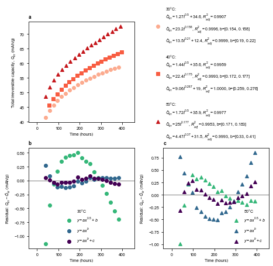

```python
colors = cm.Reds(np.linspace(0.3, 1, 4))
colors = colors[:,0:3]
markers = ['o','s','^']

Smith_labels = Labels(legend_labels = [r'$30\degree$'+'C',r'$40\degree$'+'C',r'$50\degree$'+'C'],
                      x_label = 'Time (hours)',
                      y_label = 'Total irreversible capacity, $Q_{irr}$',
                      dataset_name = 'Smith',
                      y_symbol = 'Q_{irr}',
                      y_symbol_pred = r'\hat{Q}_{irr}',
                      y_unit = '(mAh/g)',
                      switch_xy = False,
                      square_x = True)

plot_dataset(Smith_data, Smith_labels)
```

### Smith et al (paper 2)

[Link to paper](https://doi.org/10.1149/1.3625232)

We analyze the data in Figure 8b

[figure not shown]

```python
Smith2_data = load_dataset('Smith2')
```

```
['Smith2/Smith2_et_al_2011_Fig8b.csv']
```

Manual intervention:

1. For the $x$ axis, we can calculate cycle number directly instead of using the values from WebPlotDigitizer
2. For the $y$ axis, we can calculate percent capacity fade to obtain an increasing function (for consistency with other datasets). Using percent capacity fade (as opposed to fractional capacity fade) gives us more readable plots

```python
Smith2_data[0][:,0] = np.arange(len(Smith2_data[0][:,1])) + 1
Smith2_data[0][:,1] = 100*(1 - Smith2_data[0][:,1]/Smith2_data[0][0,1])
```

```python
colors = np.asarray([[0, 0, 0],
                     [0, 0, 0],
                     [0, 0, 0]])
markers = ['o']

Smith2_labels = Labels(legend_labels = [''],
                      x_label = 'Cycle number',
                      y_label = 'Capacity loss, $l$',
                      dataset_name = 'Smith2',
                      y_symbol = 'l',
                      y_symbol_pred = r'\hat{l}',
                      y_unit = '(%)',
                      switch_xy = False,
                      square_x = False)
```

Don't use `plot_dataset` function since we only have one series

```
x_max of dataset = 41.0
```

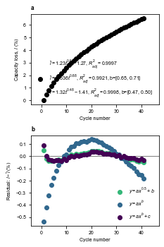

```python
n_datasets = len(Smith2_data)

# Initialize figure
plt.figure(figsize=(fig_width, fig_height*2))

# (a): Plot raw data
ax = plt.subplot(211)
plt.title('a', loc='left', weight='bold')
xlim = plot_raw_data_subplot(Smith2_data, Smith2_labels, markers)
ax.legend()

## Plot first series
plt.subplot(212)
plt.title('b',loc='left',weight='bold')
plot_residual_subplot(Smith2_data, 0, Smith2_labels, xlim, markers[0])

min_y = plt.gca().get_ylim()[0]
plt.annotate(Smith2_labels.legend_labels[0], xy=((xlim[1]-5)/2, min_y), xytext=(0, 3),
             textcoords="offset points", ha='center', va='bottom')

plt.tight_layout()
figure_filename = 'figures/{}.eps'.format(Smith2_labels.dataset_name)
plt.savefig(figure_filename, bbox_inches='tight', format='eps')
```

### Fathi et al

[Link to paper](https://doi.org/10.1149/2.0321410jes)

Because this plot was saved as a vector plot, we can more easily extract the data. (I <3 vector formats!)

Here, we focus on Groups 3 and 4 since they have the most data. We extract the data from Figure 2a since the *x* axis units are time, but we replot the data in the format of Figure 2b (and convert to units of percent).

[figure not shown]

```python
Fathi_data = load_dataset('Fathi')
```

```
['Fathi/Fathi_et_al_2014_Fig2a_group3a.csv', 'Fathi/Fathi_et_al_2014_Fig2a_group3b.csv', 'Fathi/Fathi_et_al_2014_Fig2a_group4a.csv', 'Fathi/Fathi_et_al_2014_Fig2a_group4b.csv']
```

The plot gets pretty crowded with all four datasets. I just use one series from each group:

```python
del Fathi_data[1:3]
```

Also convert this dataset to an increasing function, with nice values (%)

```python
for d in Fathi_data:
    d[:,1] = 100*(1 - d[:,1])
```

```
x_max of dataset = 10.946496253391967
```

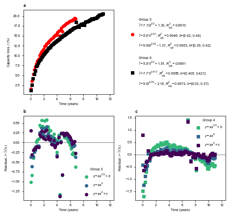

```python
colors = np.asarray([[1, 0, 0],
                     [0, 0, 0]])
markers = ['o','s']

Fathi_labels = Labels(legend_labels = ['Group 3', 'Group 4'],
                      x_label = 'Time (years)',
                      y_label = 'Capacity loss, $l$',
                      dataset_name = 'Fathi',
                      y_symbol = 'l',
                      y_symbol_pred = r'\hat{l}',
                      y_unit = '(%)',
                      switch_xy = False,
                      square_x = False)

plot_dataset(Fathi_data, Fathi_labels)
```

### Carbon black

This is data that I've collected on carbon black/Li half cells. First we preprocess the raw data:

```
['carbon black/cellA_Cover20_CB5.txt', 'carbon black/cellH_Cover20_CC2.txt', 'carbon black/cellI_Cover20_CC3.txt']
```

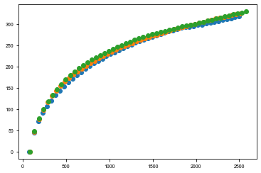

```python
author = 'carbon black'
txts = glob.glob(author + '/*.{}'.format('txt'))
txts.sort(key=sortKeyFunc)
print(txts)

# Divide by masses to get mAh/g
mass = [0.855,0.930,0.952] # cells A, H, I respectively

# Switch order for more natural ordering
txts[0], txts[1] = txts[1], txts[0]
mass[0], mass[1] = mass[1], mass[0]

time = []
SEI = []
CB_data_time = []
CB_data_cyclenum = []
CB_data_time_subfirstcycle = []
CB_data_cyclenum_subfirstcycle = []

for k, txt in enumerate(txts):
    d = np.genfromtxt(txt,skip_header=1)
    m = mass[k]/1000 # mg -> g

    #Q
    Q = d[:,2]/m # mAh -> mAh/g

    # Qd and Qc vs n
    peaks = find_peaks(Q)[0]
    Qpeaks = Q[peaks]
    Qd = Qpeaks[0::2]
    Qc = Qpeaks[1::2]

    # t (all cells cycle at C/20, with 1C = 200 mA/g -> C/20 = 10 mA/g)
    t_k = np.cumsum(Qpeaks)/10 # t = Q/I; (mAh/g / mA/g) -> h
    t_k = t_k[1::2]

    SEI_k = np.cumsum(Qd[:-1] - Qc)

    time.append(t_k) # time per cycle counts after discharge
    SEI.append(SEI_k)
    CB_data_time.append(np.vstack((t_k, SEI_k)).T)

    # Compute x as cycle number
    cyclenum_k = np.arange(len(SEI_k)) + 1
    CB_data_cyclenum.append(np.vstack((cyclenum_k, SEI_k)).T)

    SEI_k -= SEI_k[0]
    CB_data_time_subfirstcycle.append(np.vstack((t_k, SEI_k)).T)
    CB_data_cyclenum_subfirstcycle.append(np.vstack((cyclenum_k, SEI_k)).T)

    plt.plot(time[k],SEI[k],'o')
```

#### $Q_{SEI}$ vs time

```
x_max of dataset = 2574.619326000898
```

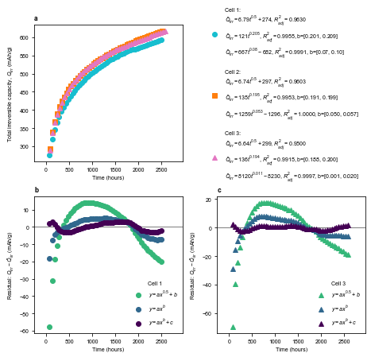

```python
colors = ['tab:cyan','tab:orange','tab:pink']
markers = ['o','s','^']

CB_labels_time = Labels(legend_labels = ['Cell 1', 'Cell 2', 'Cell 3'],
                        x_label = 'Time (hours)',
                        y_label = 'Total irreversible capacity, $Q_{irr}$',
                        dataset_name = 'CB_time',
                        y_symbol = r'Q_{irr}',
                        y_symbol_pred = r'\hat{Q}_{irr}',
                        y_unit = '(mAh/g)',
                        switch_xy = False,
                        square_x = False)

plot_dataset(CB_data_time, CB_labels_time)
```

#### $Q_{SEI}$ vs time (subtracted first cycle)

```
x_max of dataset = 2574.619326000898
```

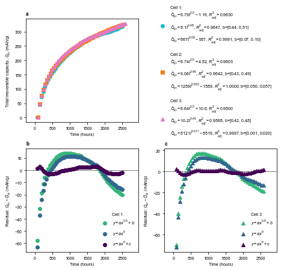

```python
colors = ['tab:cyan','tab:orange','tab:pink']
markers = ['o','s','^']

CB_labels_time_subfirstcycle = Labels(legend_labels = ['Cell 1', 'Cell 2', 'Cell 3'],
                                      x_label = 'Time (hours)',
                                      y_label = 'Total irreversible capacity, $Q_{irr}$',
                                      dataset_name = 'CB_time_subfirstcycle',
                                      y_symbol = r'Q_{irr}',
                                      y_symbol_pred = r'\hat{Q}_{irr}',
                                      y_unit = '(mAh/g)',
                                      switch_xy = False,
                                      square_x = False)

plot_dataset(CB_data_time_subfirstcycle, CB_labels_time_subfirstcycle)
```

#### $Q_{SEI}$ vs cycle number

```
x_max of dataset = 51.0
```

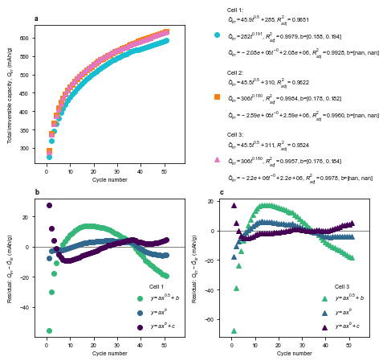

```python
colors = ['tab:cyan','tab:orange','tab:pink']
markers = ['o','s','^']

CB_labels_cyclenum = Labels(legend_labels = ['Cell 1', 'Cell 2', 'Cell 3'],
                      x_label = 'Cycle number',
                      y_label = 'Total irreversible capacity, $Q_{irr}$',
                      dataset_name = 'CB_cyclenum',
                      y_symbol = r'Q_{irr}',
                      y_symbol_pred = r'\hat{Q}_{irr}',
                      y_unit = '(mAh/g)',
                      switch_xy = False,
                      square_x = False)

plot_dataset(CB_data_cyclenum, CB_labels_cyclenum)
```